# Estudo da Base de Dados *Stellar Classification - SDSS17*

Fernando Ferreira e Thayná Santos

2026-10-22

## 1. Introdução

O presente trabalho tem como objetivo realizar uma análise exploratória do *Stellar Classification Dataset – SDSS17*, bem como proceder ao pré-processamento dos dados e à análise estatística das variáveis, com vista à posterior construção de um modelo preditivo. Para esse efeito, será aplicada a regressão logística, uma técnica estatística utilizada para modelar a probabilidade de ocorrência de um determinado resultado em função de um conjunto de variáveis explicativas. A regressão logística binária é adequada para variáveis de resposta dicotómicas e a sua aplicação a problemas com mais de duas categorias requer uma adaptação do problema a uma classificação binária.

O dataset em estudo contém 100.000 observações e 17 variáveis explicativas, que incluem características fotométricas, coordenadas astronómicas e outras informações relativas aos objetos observados. Com base nestas características, classifica-se os objetos astronómicos em três categorias distintas: estrelas (*stars*), galáxias (*galaxies*) e quasares (*quasars*). A análise destas variáveis permitirá compreender melhor os dados e identificar as características potencialmente relevantes para a capacidade preditiva do modelo.

Uma vez que o objetivo deste trabalho passa pela aplicação da regressão logística binária, será necessário selecionar duas das três classes existentes, transformando o problema original numa tarefa de classificação binária. Esta seleção será acompanhada por procedimentos de pré-processamento e limpeza dos dados, de modo a garantir a sua qualidade e adequação à modelação. Por fim, o desempenho do modelo será avaliado com base em métricas apropriadas, permitindo analisar a sua capacidade de classificação e a qualidade das previsões obtidas.

## 2. Descrição da Base de Dados

A classificação estelar é uma área fundamental da astronomia, permitindo identificar e distinguir diferentes objetos celestes com base nas suas características espectrais. O *Stellar Classification Dataset - SDSS17* baseia-se em dados recolhidos pelo *Sloan Digital Sky Survey* (SDSS), tendo como objetivo classificar objetos astronómicos em três categorias: estrelas (*stars*), galáxias (*galaxies*) e quasares (*quasars*).

O dataset contém **100 000 observações e 18 variáveis**, das quais 17 correspondem a características dos objetos observados e uma variável de resposta, denominada `class`, que identifica a respetiva categoria. As variáveis são as seguintes:

- **`obj_ID`**: identificador único do objeto no catálogo de imagens astronómicas.
- **`alpha`**: ascensão reta do objeto, correspondente à coordenada astronómica que permite determinar a sua posição no céu, no referencial J2000.
- **`delta`**: declinação do objeto, correspondente à coordenada astronómica que indica a sua posição angular relativamente ao equador celeste, no referencial J2000.
- **`u`**: magnitude fotométrica medida através do filtro ultravioleta.
- **`g`**: magnitude fotométrica medida através do filtro verde.
- **`r`**: magnitude fotométrica medida através do filtro vermelho.
- **`i`**: magnitude fotométrica medida através do filtro do infravermelho próximo.
- **`z`**: magnitude fotométrica medida através do filtro infravermelho.
- **`run_ID`**: identificador da execução de observação (*run*), utilizado para identificar uma digitalização específica do levantamento astronómico.
- **`rerun_ID`**: identificador do reprocessamento das imagens, permitindo distinguir diferentes processamentos dos dados recolhidos.
- **`cam_col`**: número da coluna da câmara, utilizado para identificar a linha de digitalização dentro de uma execução de observação.
- **`field_ID`**: identificador do campo de observação, utilizado para distinguir as diferentes regiões observadas.
- **`spec_obj_ID`**: identificador único dos objetos observados por espectroscopia ótica. Observações com o mesmo identificador partilham a mesma classificação.
- **`class` (variável resposta)**: categoria do objeto astronómico observado, podendo assumir três valores: estrela (*STAR*), galáxia (*GALAXY*) ou quasar (*QSO*).
- **`redshift`**: desvio para o vermelho, que quantifica o aumento do comprimento de onda da luz recebida relativamente ao seu valor original, sendo relevante para o estudo do movimento e da distância cosmológica dos objetos.
- **`plate`**: identificador da placa utilizada no SDSS para a recolha dos dados espectroscópicos.
- **`MJD`**: *Modified Julian Date*, variável que indica a data em que os dados foram recolhidos, expressa numa escala de tempo astronómica.
- **`fiber_ID`**: identificador da fibra ótica utilizada para captar a luz do objeto observado no plano focal do instrumento.

A base de dados é assim representada:

|  | obj_ID | alpha | delta | u | g | r | i | z | run_ID | rerun_ID | cam_col | field_ID | spec_obj_ID | class | redshift | plate | MJD | fiber_ID |
| --- | --- | --- | --- | --- | --- | --- | --- | --- | --- | --- | --- | --- | --- | --- | --- | --- | --- | --- |
| 1 | 1.237660961327743e+18 | 135.6891066036 | 32.4946318397087 | 23.87882 | 22.2753 | 20.39501 | 19.16573 | 18.79371 | 3606 | 301 | 2 | 79 | 6.543777369295182e+18 | GALAXY | 0.6347936 | 5812 | 56354 | 171 |
| 2 | 1.237664879951151e+18 | 144.826100550256 | 31.2741848944939 | 24.77759 | 22.83188 | 22.58444 | 21.16812 | 21.61427 | 4518 | 301 | 5 | 119 | 1.176014203670733e+19 | GALAXY | 0.779136 | 10445 | 58158 | 427 |
| 3 | 1.23766096133043e+18 | 142.188789562506 | 35.5824441819976 | 25.26307 | 22.66389 | 20.60976 | 19.34857 | 18.94827 | 3606 | 301 | 2 | 120 | 5.152200256025549e+18 | GALAXY | 0.6441945 | 4576 | 55592 | 299 |
| 4 | 1.237663478724298e+18 | 338.741037753146 | -0.402827574587482 | 22.13682 | 23.77656 | 21.61162 | 20.50454 | 19.2501 | 4192 | 301 | 3 | 214 | 1.030107141295442e+19 | GALAXY | 0.9323456 | 9149 | 58039 | 775 |
| 5 | 1.237680272041378e+18 | 345.282593210935 | 21.1838656010284 | 19.43718 | 17.58028 | 16.49747 | 15.97711 | 15.54461 | 8102 | 301 | 3 | 137 | 6.891864880783317e+18 | GALAXY | 0.1161227 | 6121 | 56187 | 842 |
| 6 | 1.237680272039609e+18 | 340.995120509191 | 20.5894762801019 | 23.48827 | 23.33776 | 21.32195 | 20.25615 | 19.54544 | 8102 | 301 | 3 | 110 | 5.658976714552007e+18 | QSO | 1.424659 | 5026 | 55855 | 741 |
| 7 | 1.237678858481566e+18 | 23.2349264301638 | 11.4181876197835 | 21.46973 | 21.17624 | 20.92829 | 20.60826 | 20.42573 | 7773 | 301 | 2 | 462 | 1.2462617271914e+19 | QSO | 0.5864546 | 11069 | 58456 | 113 |
| 8 | 1.237678858473964e+18 | 5.43317603738404 | 12.0651859913473 | 22.24979 | 22.02172 | 20.34126 | 19.48794 | 18.84999 | 7773 | 301 | 2 | 346 | 6.961443351364393e+18 | GALAXY | 0.477009 | 6183 | 56210 | 15 |
| 9 | 1.23766143538666e+18 | 200.290475389797 | 47.199402322911 | 24.40286 | 22.35669 | 20.61032 | 19.4649 | 18.95852 | 3716 | 301 | 5 | 108 | 7.459284627188111e+18 | GALAXY | 0.660012 | 6625 | 56386 | 719 |
| 10 | 1.237670961088168e+18 | 39.1496905996484 | 28.1028416109607 | 21.74669 | 20.03493 | 19.17553 | 18.81823 | 18.65422 | 5934 | 301 | 4 | 122 | 2.751763212482406e+18 | STAR | -7.895373e-06 | 2444 | 54082 | 232 |

[output cut: 99990 more lines]

## 3. Tratamento de Dados

### 3.1. Tratamento da variável de resposta

A variável `class` foi identificada como a variável categórica de resposta, uma vez que permite classificar os objetos astronómicos em três categorias distintas: estrela (*STAR*), galáxia (*GALAXY*) ou quasar (*QSO*). Através da função `str()`, verificou-se que esta variável se encontrava armazenada como texto (character). Assim, procedeu-se à sua conversão para fator (`factor), de modo a representar explicitamente a sua natureza categórica e facilitar a realização das análises estatísticas subsequentes.

```r
str(data$class)                     # a variavel class não é um fator, então devemos convertê-la
```

```
##  chr [1:100000] "GALAXY" "GALAXY" "GALAXY" "GALAXY" "GALAXY" "QSO" "QSO" ...
```

```r
summary(data$class)
```

```
##    Length  N.unique   N.blank Min.nchar Max.nchar
##    100000         3         0         3         6
```

```r
data$class <- as.factor(data$class)
summary(data$class)
```

```
## GALAXY    QSO   STAR
##  59445  18961  21594
```

Com o objetivo de aplicar um modelo de regressão logística binária, optou-se por restringir a análise às classes *STAR* (estrelas) e *GALAXY* (galáxias), excluindo as observações pertencentes à classe *QSO* (quasares) de menor frequência. Esta decisão permite formular o problema de classificação como uma distinção entre duas categorias.

Após a remoção das observações da classe *QSO*, eliminaram-se também os níveis do fator que deixaram de estar representados na base de dados, garantindo que a variável de resposta contém apenas as duas classes consideradas na análise.

```r
data <- subset(data, class != "QSO") # Remover todas as observações da classe QSO
data$class <- droplevels(data$class) # Remover os níveis do fator que já não têm observações

summary(data$class)
```

```
## GALAXY   STAR
##  59445  21594
```

```r
levels(data$class)
```

```
## [1] "GALAXY" "STAR"
```

### 3.2. Tratamento dos identificadores dos objetos

Foram identificadas duas variáveis com funções essencialmente identificadoras: `obj_ID`, que identifica o objeto no catálogo de imagens, e `spec_obj_ID`, que identifica os objetos observados por espectroscopia ótica. Embora sejam representadas numericamente, estas variáveis não correspondem a propriedades físicas dos astros. A sua utilização direta como variáveis explicativas poderia levar o modelo a aprender associações artificiais (vieses) entre os identificadores e a classe dos objetos, sem garantir capacidade de generalização para novas observações. Assim, optou-se por excluí-las do conjunto de variáveis preditoras.

```r
data$obj_ID <- NULL
data$spec_obj_ID <- NULL
```

Variáveis como `run_ID`, que identifica a execução de uma observação, e `rerun_ID`, precisam de uma observação mais detalhada quanto às suas distribuições numéricas.

```r
data$run_ID <- factor(data$run_ID)
summary(data$run_ID)
```

```
##    4263    3699    3225    5935    2964    3926    7717    7773    1412    4576
##    1825    1800    1783    1504    1490    1341    1251    1244    1208    1132
##    4849    5061    2830    3606    1140    8103    4649    5183    4192    3705
##    1127    1122    1081     999     952     931     886     876     856     833
##    7712    3560    5322    5194    2074    3919    4512    1740    4552    3841
##     820     810     799     788     774     763     717     658     639     638
##    4188    3918    2247    3698    4264    1458    4518    4858    7881    4670
##     637     609     600     582     580     577     569     549     544     535
##    3180    5137    6573    5314    3840    2243    7865    3900    2700    2125
##     525     515     508     502     483     469     469     468     462     451
##    4504    2821    4294    7778    2335    3647    3893    3605    8096    2379
##     450     449     438     435     424     421     421     416     408     401
##    2076    4187    7708     752    4469    6354    8156    3187    1402    2986
##     380     370     367     365     359     352     346     341     330     329
##    4671    1737    3438    3650     756    5112    7907    2825    5934    7880
##     329     328     323     321     320     315     310     308     305     300
##    7917    5972    7713    1739    4335    3015    5045    2078    3838    4874
##     300     298     297     294     293     284     282     280     280     279
##    1302    8108    2206    3704    3927    4470    5313    4678    7780 (Other)
##     275     274     272     268     264     260     259     254     253   22531
```

```r
data$rerun_ID <- factor(data$rerun_ID)
summary(data$rerun_ID)
```

```
##   301
## 81039
```

Como todas as observações têm `rerun_ID = 301`, não existe qualquer diferença nesta variável entre estrelas e galáxias que o modelo possa utilizar para as distinguir. Por conseguinte, é justificável excluir `rerun_ID` do conjunto de variáveis explicativas, uma vez que não apresenta variabilidade nos dados. De forma análoga, `run_ID` identifica a execução em que os dados foram recolhidos, e não uma característica física intrínseca dos objetos, optou-se por não a incluir no modelo preditivo inicial.

```r
data$rerun_ID <- NULL
data$run_ID <- NULL
```

### 3.3. Tratamento das restantes variáveis relacionadas com a aquisição

Por fim, foram analisadas outras variáveis relacionadas com o processo de aquisição dos dados, nomeadamente `cam_col`, `field_ID`, `fiber_ID`, `plate`, e `MJD`. Estas variáveis identificam elementos da localização, da organização instrumental ou da recolha das observações, não correspondendo diretamente a propriedades físicas intrínsecas dos objetos astronómicos. Assim, optou-se por excluí-las do modelo preditivo inicial, privilegiando as variáveis que caracterizam as propriedades astronómicas dos objetos.

```r
data$MJD <- NULL
data$plate <- NULL
data$cam_col <- NULL
data$field_ID <- NULL
data$fiber_ID <- NULL
```

### 3.4 Verificação da existência de valores em falta

Um dos principais tópicos a abordar no tratamento de base de dados consiste no tratamento de valores em falta. Assim, precisamos observar a existência desses valores na base de dados sendo trabalhada, a fim de identificar a necessidade da aplicação de técnicas adicionais no tratamento desses dados.

```r
sapply(data, function(x) sum(is.na(x)))
```

```
##    alpha    delta        u        g        r        i        z    class
##        0        0        0        0        0        0        0        0
## redshift
##        0
```

A partir da função acima, atestamos a inexistência de valores em falta explícitos (NA).

### 3.5 Verificação e tratamento de valores sentinela

|  | alpha | delta | u | g | r | i | z | class | redshift |
| --- | --- | --- | --- | --- | --- | --- | --- | --- | --- |
|  | Min. : 0.00553 | Min. :-18.785 | Min. :-9999.00 | Min. :-9999.00 | Min. : 9.822 | Min. : 9.47 | Min. :-9999.00 | GALAXY:59445 | Min. :-0.0099707 |
|  | 1st Qu.:127.16525 | 1st Qu.: 4.642 | 1st Qu.: 20.24 | 1st Qu.: 18.59 | 1st Qu.:17.726 | 1st Qu.:17.33 | 1st Qu.: 17.06 | STAR :21594 | 1st Qu.: 0.0003113 |
|  | Median :179.98225 | Median : 22.548 | Median : 22.49 | Median : 21.12 | Median :19.807 | Median :19.06 | Median : 18.66 | NA | Median : 0.2476218 |
|  | Mean :176.96341 | Mean : 23.510 | Mean : 22.08 | Mean : 20.44 | Mean :19.417 | Mean :18.77 | Mean : 18.29 | NA | Mean : 0.3092252 |
|  | 3rd Qu.:233.36720 | 3rd Qu.: 38.699 | 3rd Qu.: 23.95 | 3rd Qu.: 22.26 | 3rd Qu.:20.887 | 3rd Qu.:19.96 | 3rd Qu.: 19.51 | NA | 3rd Qu.: 0.5425091 |
|  | Max. :359.99981 | Max. : 83.001 | Max. : 30.66 | Max. : 31.60 | Max. :29.572 | Max. :30.25 | Max. : 29.38 | NA | Max. : 1.9955240 |

A análise das estatísticas descritivas revela uma inconsistência nas variáveis `u`, `g` e `z`: o valor mínimo observado é -9999, fisicamente impossível para uma magnitude fotométrica. Trata-se de um código sentinela utilizado pelo SDSS para indicar ausência de medição, ou seja, um valor em falta codificado numericamente, que a função `is.na()` não consegue detetar. Antes de prosseguir com a análise gráfica, é necessário tratar estes registos, uma vez que distorcem a escala dos gráficos e as medidas de resumo.

Verifiquemos quantas observações são afetadas:

```
##    alpha    delta        u        g        r        i        z redshift
##        0        0        1        1        0        0        1        0
```

```
## # A tibble: 1 × 9
##   alpha  delta     u     g     r     i     z class  redshift
##   <dbl>  <dbl> <dbl> <dbl> <dbl> <dbl> <dbl> <fct>     <dbl>
## 1  224. -0.624 -9999 -9999  18.2  18.0 -9999 STAR  0.0000893
```

Dado o número muito reduzido de observações afetadas face ao total, optou-se pela sua remoção, uma vez que a imputação seria difícil de justificar (a magnitude num filtro não se infere de forma fiável a partir de um único registo) e a eliminação não compromete a representatividade da amostra.

```r
data[vars_num] <- lapply(data[vars_num], function(x) replace(x, x == -9999, NA))
data <- na.omit(data)
nrow(data)
```

```
## [1] 81038
```

```r
summary(data[vars_num])
```

```
##      alpha               delta               u               g
##  Min.   :  0.00553   Min.   :-18.785   Min.   :12.10   Min.   :10.50
##  1st Qu.:127.16422   1st Qu.:  4.642   1st Qu.:20.24   1st Qu.:18.59
##  Median :179.98054   Median : 22.549   Median :22.49   Median :21.12
##  Mean   :176.96283   Mean   : 23.510   Mean   :22.21   Mean   :20.56
##  3rd Qu.:233.36895   3rd Qu.: 38.700   3rd Qu.:23.95   3rd Qu.:22.26
##  Max.   :359.99981   Max.   : 83.001   Max.   :30.66   Max.   :31.60
##        r                i               z             redshift
##  Min.   : 9.822   Min.   : 9.47   Min.   : 9.612   Min.   :-0.0099707
##  1st Qu.:17.726   1st Qu.:17.33   1st Qu.:17.063   1st Qu.: 0.0003114
##  Median :19.807   Median :19.06   Median :18.661   Median : 0.2476382
##  Mean   :19.417   Mean   :18.77   Mean   :18.419   Mean   : 0.3092290
##  3rd Qu.:20.887   3rd Qu.:19.96   3rd Qu.:19.514   3rd Qu.: 0.5425107
##  Max.   :29.572   Max.   :30.25   Max.   :29.384   Max.   : 1.9955240
```

Após a remoção, o `summary()` confirma que as variáveis passaram a apresentar intervalos fisicamente plausíveis.

### 3.6 Normalização dos dados

Normalização dos dados é um passo importante no tratamento de dados, uma vez que torna a escala dos dados comparável, prevenindo que variáveis de magnitude maior impactem o modelo de forma tendenciosa. Além disso, esta técnica acelera a convergência do modelo e faz com que todas as variaveis contribuam de forma semelhante para a medição.

Um exemplo da necessidade dessa operação é a variável `alpha`, que possui uma amplitude de 360.

```r
data[vars_num] <- lapply(data[vars_num], function(x) {
  xmin <- min(x)
  xmax <- max(x)

  if (xmax == xmin) {
    return(rep(0, length(x)))
  }

  (x - xmin) / (xmax - xmin)
})

summary(data[vars_num])
```

```
##      alpha            delta              u                g
##  Min.   :0.0000   Min.   :0.0000   Min.   :0.0000   Min.   :0.0000
##  1st Qu.:0.3532   1st Qu.:0.2302   1st Qu.:0.4383   1st Qu.:0.3835
##  Median :0.4999   Median :0.4061   Median :0.5598   Median :0.5034
##  Mean   :0.4916   Mean   :0.4155   Mean   :0.5444   Mean   :0.4769
##  3rd Qu.:0.6482   3rd Qu.:0.5648   3rd Qu.:0.6387   3rd Qu.:0.5575
##  Max.   :1.0000   Max.   :1.0000   Max.   :1.0000   Max.   :1.0000
##        r                i                z             redshift
##  Min.   :0.0000   Min.   :0.0000   Min.   :0.0000   Min.   :0.000000
##  1st Qu.:0.4002   1st Qu.:0.3781   1st Qu.:0.3768   1st Qu.:0.005127
##  Median :0.5056   Median :0.4613   Median :0.4576   Median :0.128452
##  Mean   :0.4858   Mean   :0.4475   Mean   :0.4454   Mean   :0.159163
##  3rd Qu.:0.5603   3rd Qu.:0.5050   3rd Qu.:0.5008   3rd Qu.:0.275484
##  Max.   :1.0000   Max.   :1.0000   Max.   :1.0000   Max.   :1.000000
```

## 4. Análise Exploratória Gráfica

Agora, faremos a análise exploratória gráfica a fim de observar o comportamento das variáveis através de algumas estatísticas descritivas:

### 4.2 Variável Categórica - `class`:

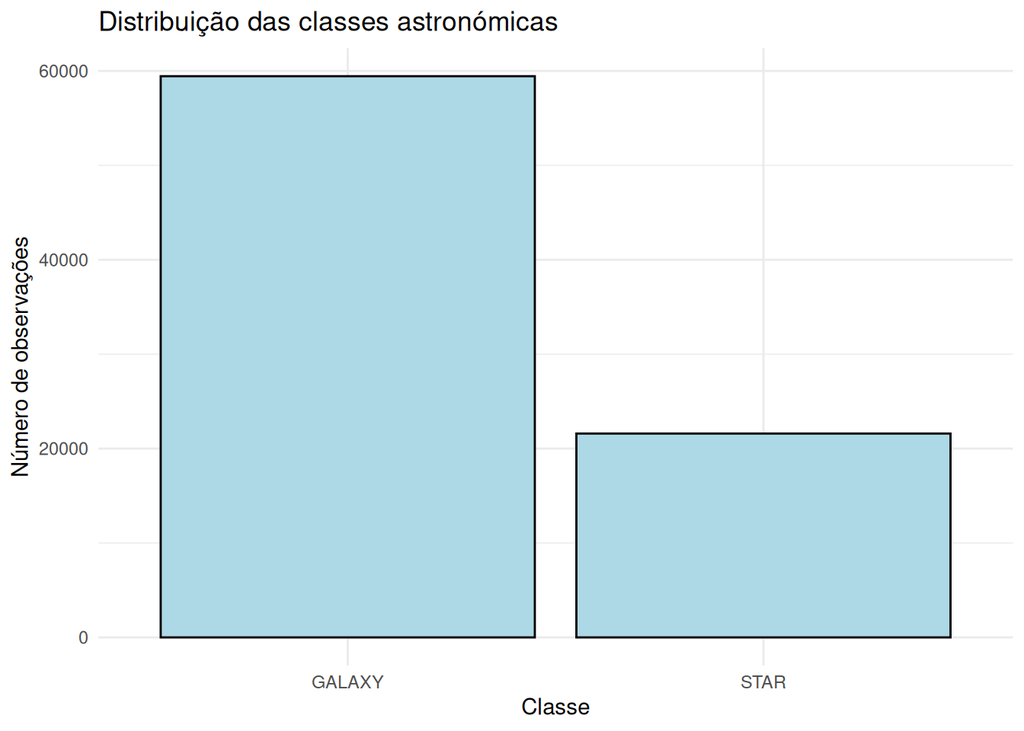

A partir do gráfico de barras acima, vemos que as classes não são balancedas.

### 4.3 Variáveis Numéricas - `alpha`, `delta`, `u`, `g`, `r`, `i`, `z`, `redshift`:

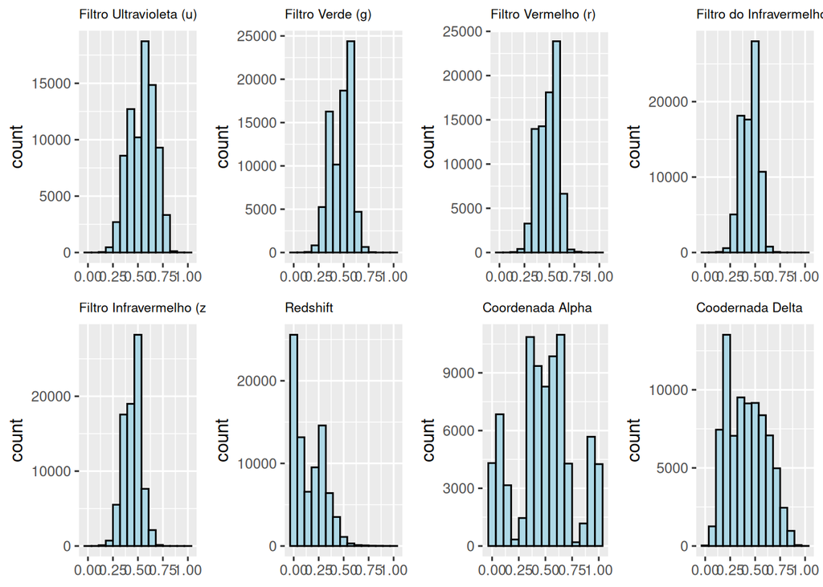

### 4.4 Boxplots

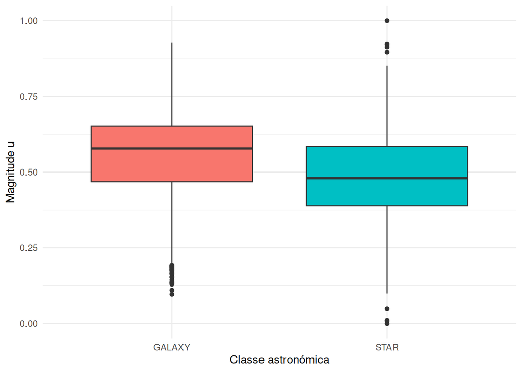

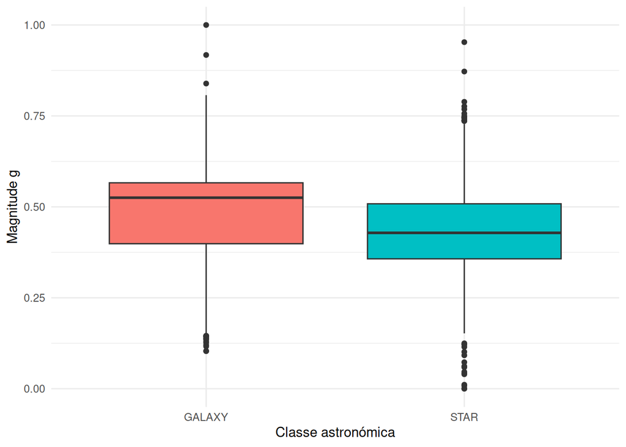

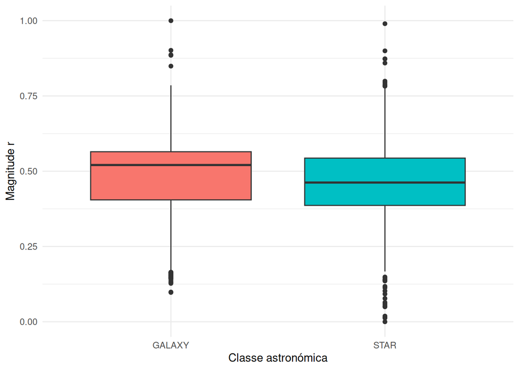

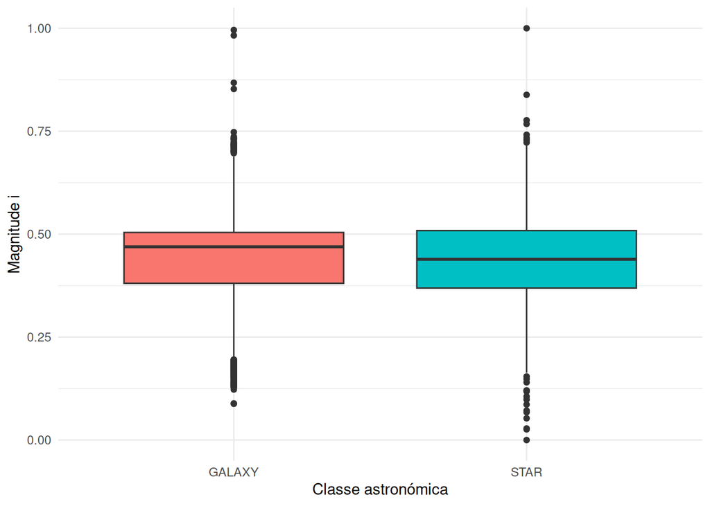

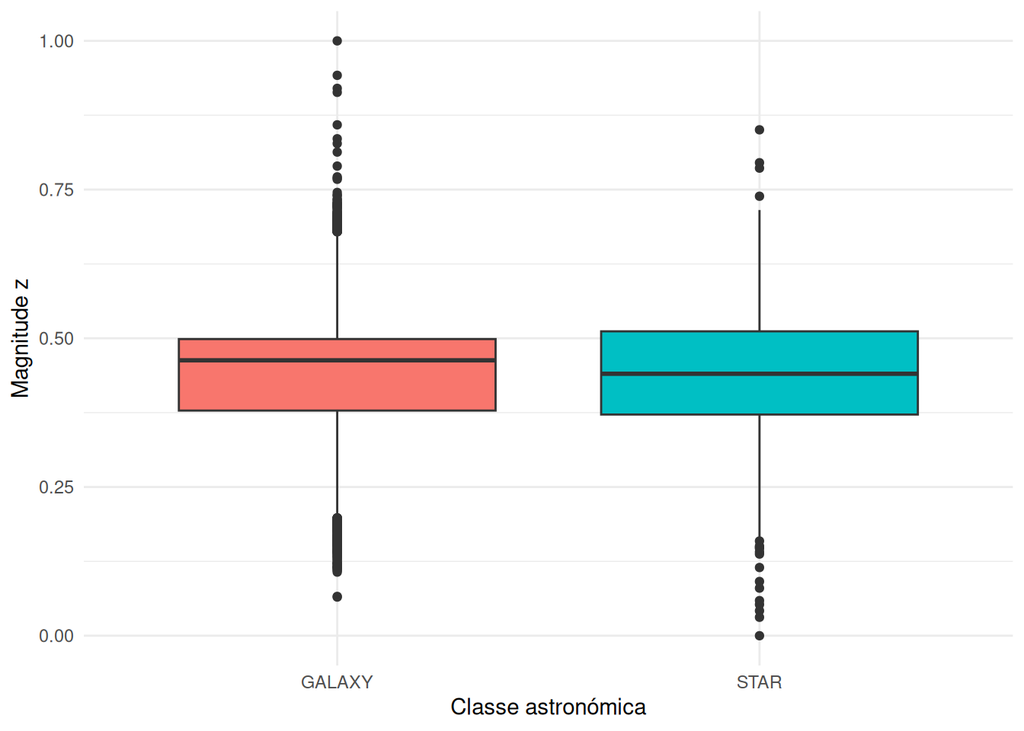

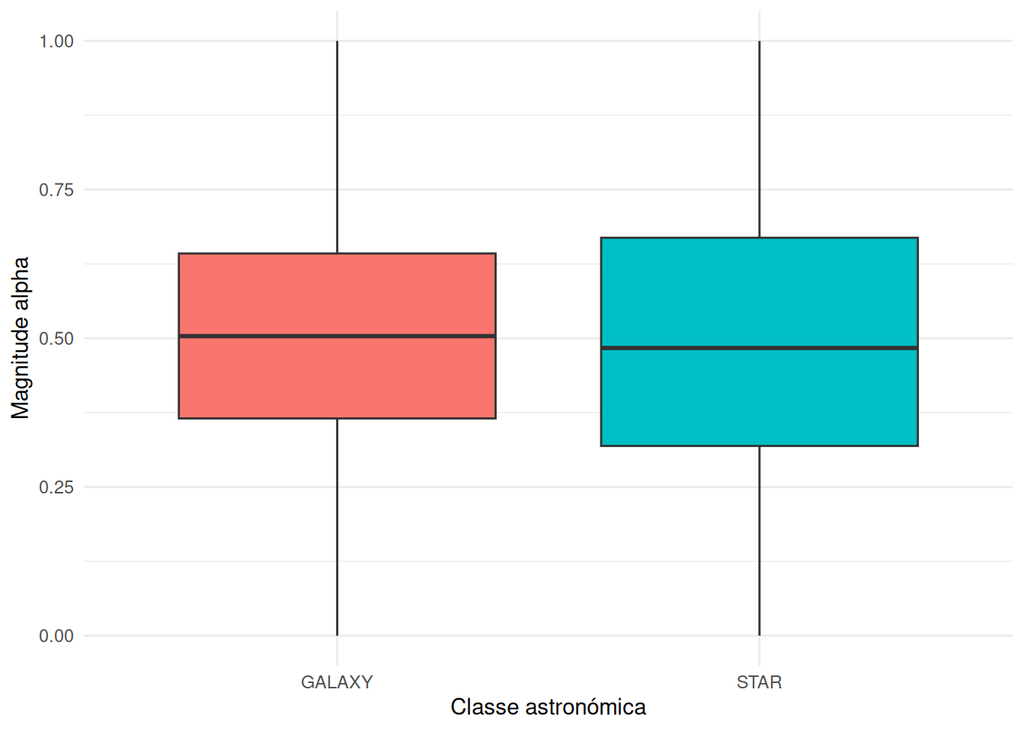

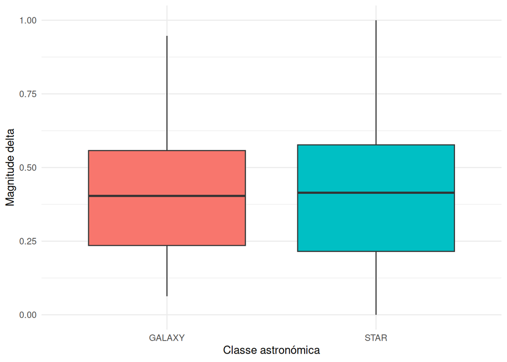

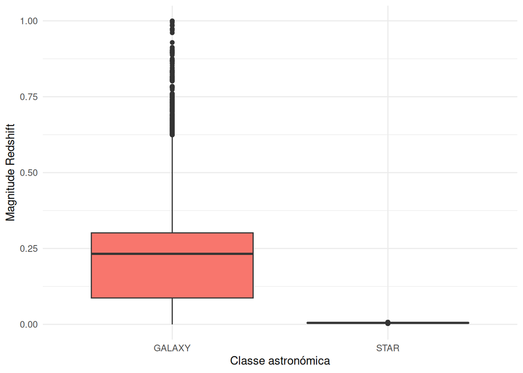

Observa-se que para a maioria das variáveis as medianas muito próximas e as classes se sobrepõem bastante, indicando que essas variáveis não distinguem bem estrelas de galáxias. Já a variável `redshift` presenta comportamento bem diferente: as estrelas concentram-se em valores próximos de zero, enquanto as galáxias assumem valores mais altos, com sobreposição muito pequena entre as classes. Isso indica que o redshift tem grande capacidade de separar as duas classes, o que é coerente com os resultados do teste t e da regressão logística.

## 5. Análise Estatística Primária

Testes da normalidade podem ser visuais, através de qqplot ou da densidade das variáveis, e analíticos, através do teste Kolmogorov-Smirnov e Shapiro-Wilk.

### 5.1 Métodos visuais

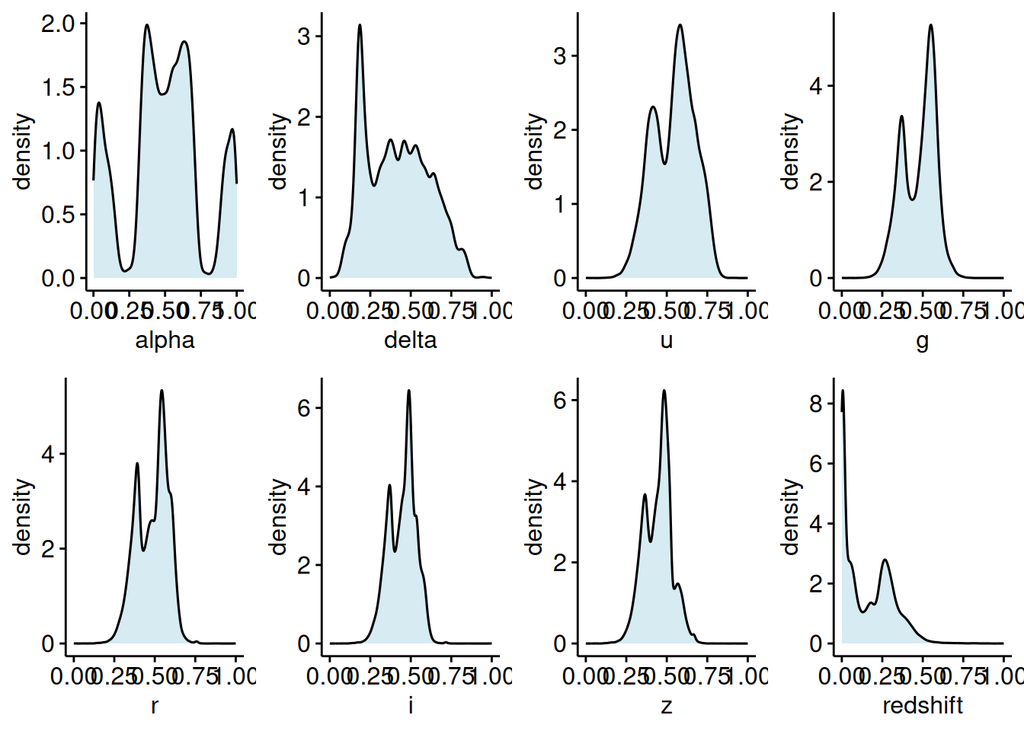

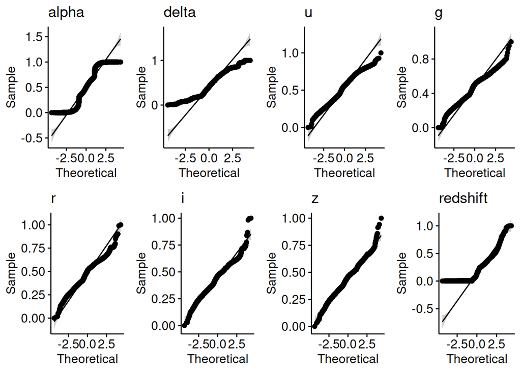

Os gráficos Q-Q indicam que as variáveis se dividem em dois grupos. `alpha`, `delta` e `redshift` afastam-se claramente da reta de referência: `alpha` e `delta` apresentam formato de “S” com patamares, e o `redshift` acumula pontos próximos de zero com curvatura acentuada, coerente com sua forte assimetria à direita. Já as magnitudes `u`, `g`, `r`, `i` e `z` acompanham razoavelmente a reta na região central, afastando-se apenas nas extremidades, sobretudo na cauda superior, o que indica distribuições aproximadamente normais, com alguns valores extremos à direita. Assim, nenhuma variável é perfeitamente normal, mas as magnitudes se aproximam bem mais desse comportamento do que as demais.

### 5.2 Testes Analíticos

Dada a quantidade de observações na base de dados, para a realização do teste de Shapiro-Wilk, precisamos selecionar uma amostra aleatória de, no máximo, 5000 observações por variável, devido à limitação da função em R.

|  | alpha_p_value | delta_p_value | u_p_value | g_p_value | r_p_value | i_p_value | z_p_value | redshift_p_value |
| --- | --- | --- | --- | --- | --- | --- | --- | --- |
| 1 | 7.367502928269057e-36 | 3.622585389900927e-33 | 1.487858442979796e-22 | 9.992536605326165e-34 | 8.430106927346804e-31 | 5.29266355672539e-22 | 1.246935479640209e-17 | 2.853656372363247e-50 |

Todos os p-valores obtidos são extremamente pequenos, muito inferiores a qualquer nível de significância usual (α = 0,05 ou 0,01). Assim, rejeita-se a hipótese nula de normalidade para todas as variáveis (`alpha`, `delta`, `u`, `g`, `r`, `i`, `z` e `redshift`).

### 5.3 Testes comparativos: numérico vs binário

```
## $alpha
##
##  Welch Two Sample t-test
##
## data:  x by data$class
## t = 4.7588, df = 36484, p-value = 1.955e-06
## alternative hypothesis: true difference in means between group GALAXY and group STAR is not equal to 0
## 95 percent confidence interval:
##  0.006081562 0.014599581
## sample estimates:
## mean in group GALAXY   mean in group STAR
##            0.4943112            0.4839706
##
##
## $delta
##
##  Welch Two Sample t-test
##
## data:  x by data$class
## t = 0.089141, df = 36562, p-value = 0.929
## alternative hypothesis: true difference in means between group GALAXY and group STAR is not equal to 0
## 95 percent confidence interval:
##  -0.002936129  0.003215921
## sample estimates:
## mean in group GALAXY   mean in group STAR
##            0.4155709            0.4154310
##
##
## $u
##
##  Welch Two Sample t-test
##
## data:  x by data$class
## t = 77.259, df = 36940, p-value < 2.2e-16
## alternative hypothesis: true difference in means between group GALAXY and group STAR is not equal to 0
## 95 percent confidence interval:
##  0.07528435 0.07920366
## sample estimates:
## mean in group GALAXY   mean in group STAR
##            0.5650015            0.4877575
```

[output cut: 55 more lines]

```
##            0.4469497            0.4411402
##
##
## $redshift
##
##  Welch Two Sample t-test
##
## data:  x by data$class
## t = 388.2, df = 59445, p-value < 2.2e-16
## alternative hypothesis: true difference in means between group GALAXY and group STAR is not equal to 0
## 95 percent confidence interval:
##  0.2092161 0.2113395
## sample estimates:
## mean in group GALAXY   mean in group STAR
##          0.215192204          0.004914379
```

Após a normalização dos dados e do tratamento dos valores sentinela (-9999), comparamos as médias de estrelas (*STAR*) e galáxias (*GALAXY*) usando o teste t de Welch. O resultado foi que as duas classes têm médias diferentes em quase todas as variáveis. A única exceção foi `delta`, que não mostrou diferença.

A variável que mais separa as classes é o `redshift`: a média das galáxias é cerca de 0,21, enquanto a das estrelas é praticamente zero. Isso faz sentido, pois as estrelas estão perto de nós e as galáxias estão muito mais distantes.

Nas magnitudes, as galáxias têm valores maiores que as estrelas, ou seja, são menos brilhantes. A diferença é maior nos filtros `u` (≈ 0,077) e `g` (≈ 0,06), e vai diminuindo em `r` (≈ 0,03), `i` (≈ 0,02) e `z` (≈ 0,005).

Em alpha, a diferença é pequena (≈ 0,01), refletindo a região do céu observada, e não uma característica real dos objetos.

Assim, `redshift`, `u`, `g` e `r` são as variáveis mais promissoras para distinguir galáxias de estrelas no modelo.

### 5.4 Testes comparativos: numérico vs numérico

Agora, avaliaremos a associação entre atributos numéricos através da correlação de Spearman.

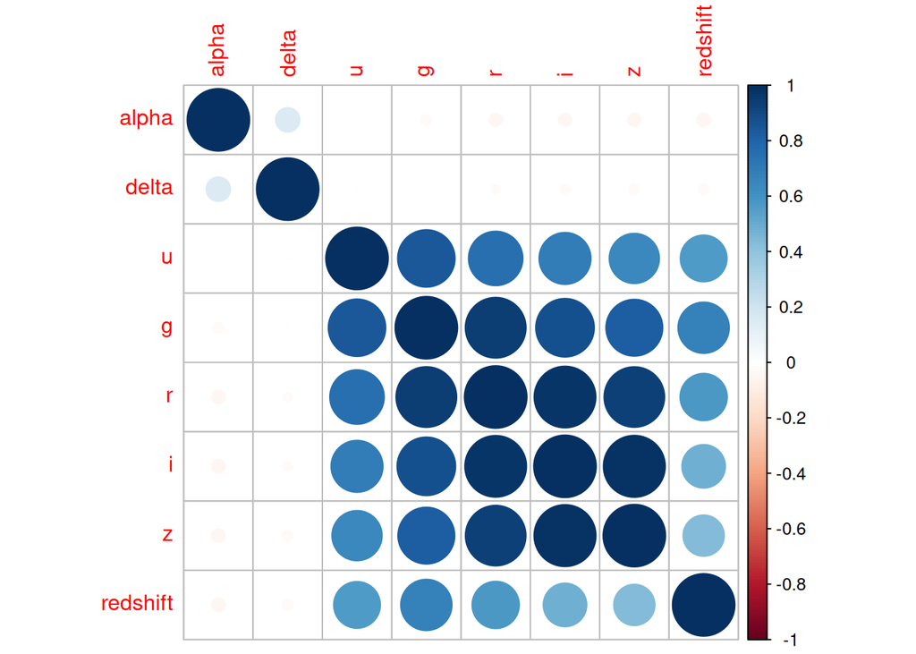

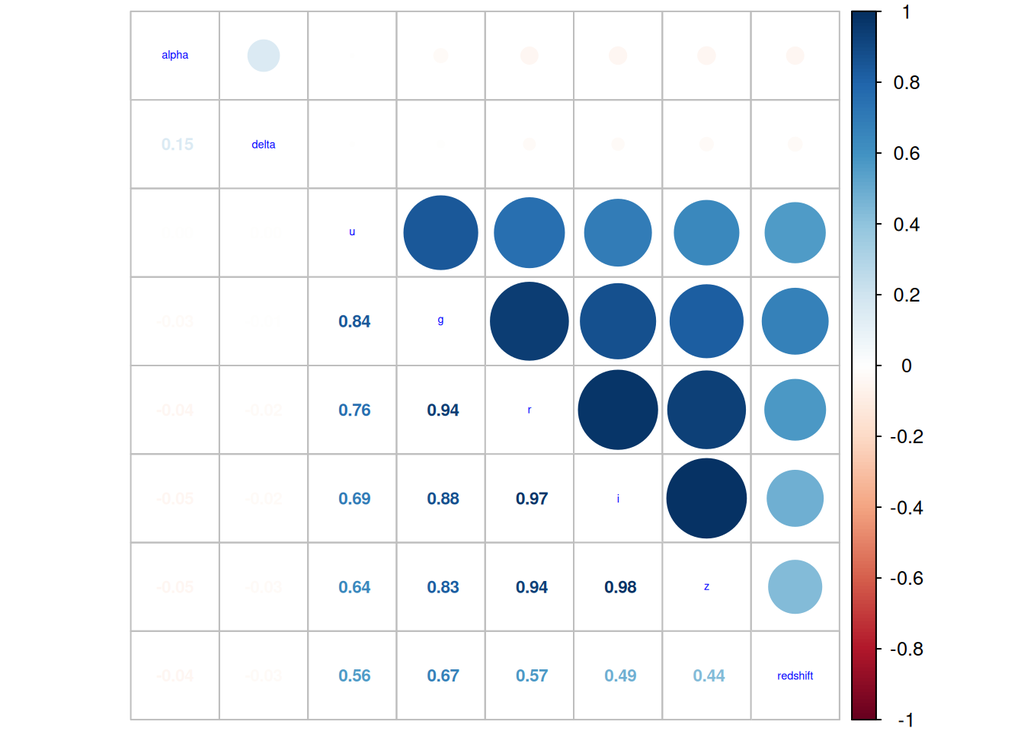

## 6. Criação dos Modelos

Feita a análise, o tratamento e a exploração dos dados podemos agora criar os modelos.

```
## [1] 56728
```

```
## [1] 24310
```

```
##
## Call:
## glm(formula = class ~ alpha + delta + u + g + r + i + z + redshift,
##     family = binomial(link = logit), data = train_data)
##
## Coefficients:
##               Estimate Std. Error z value Pr(>|z|)
## (Intercept)  1.469e+01  6.133e-01  23.946  < 2e-16 ***
## alpha       -8.598e-02  2.104e-01  -0.409  0.68283
## delta       -6.178e-01  2.767e-01  -2.232  0.02560 *
## u            2.276e+00  9.591e-01   2.373  0.01766 *
## g           -8.969e+00  1.589e+00  -5.646 1.64e-08 ***
## r            6.122e+00  2.297e+00   2.666  0.00768 **
## i           -4.063e+00  2.657e+00  -1.529  0.12623
## z            7.330e-02  1.617e+00   0.045  0.96384
## redshift    -1.784e+03  9.802e+01 -18.202  < 2e-16 ***
## ---
## Signif. codes:  0 '***' 0.001 '**' 0.01 '*' 0.05 '.' 0.1 ' ' 1
##
## (Dispersion parameter for binomial family taken to be 1)
##
##     Null deviance: 65772  on 56727  degrees of freedom
## Residual deviance:  3256  on 56719  degrees of freedom
## AIC: 3274
##
## Number of Fisher Scoring iterations: 17
```

```
##   (Intercept)         alpha         delta             u             g
##  1.468614e+01 -8.598188e-02 -6.177525e-01  2.275582e+00 -8.969302e+00
##             r             i             z      redshift
##  6.122348e+00 -4.062554e+00  7.329628e-02 -1.784162e+03
```

```
##                     2.5 %        97.5 %
## (Intercept)    13.5083728  1.591213e+01
## alpha          -0.4967495  3.286466e-01
## delta          -1.1598946 -7.457917e-02
## u               0.4036336  4.163567e+00
## g             -11.9689166 -5.703680e+00
## r               1.5046114  1.048007e+01
## i              -9.1908881  1.112898e+00
## z              -2.9775382  3.357783e+00
## redshift    -1982.3061679 -1.598279e+03
```

```
##        alpha        delta            u            g            r            i
## 9.176109e-01 5.391548e-01 9.733586e+00 1.272570e-04 4.559342e+02 1.720502e-02
##            z     redshift
## 1.076049e+00 0.000000e+00
```

```
##                    2.5 %       97.5 %
## (Intercept) 7.355493e+05 8.138628e+06
## alpha       6.085054e-01 1.389087e+00
## delta       3.135192e-01 9.281340e-01
## u           1.497255e+00 6.430045e+01
## g           6.338195e-06 3.333677e-03
## r           4.502403e+00 3.559886e+04
## i           1.019643e-04 3.043166e+00
## z           5.091803e-02 2.872544e+01
## redshift    0.000000e+00 0.000000e+00
```

Foi observado no resultado que a variável `redshift` apresenta um coeficiente extremo, originando um intervalo de confiança para a *Odds Ratio* de [0, 0] devido a underflow numérico. O facto de o algoritmo ter necessitado de 17 iterações para convergir revela que o redshift está a causar Separação Perfeita. Ou seja, o modelo consegue distinguir as classes com um nível de certeza irrealista apenas com esta variável. Para evitar o enviesamento do algoritmo e avaliar a capacidade preditiva das variáveis fotométricas, optou-se por remover o `redshift`.

```
##
## Call:
## glm(formula = class ~ redshift + alpha + delta + u + g + r, family = binomial(link = logit),
##     data = train_data)
##
## Coefficients:
##               Estimate Std. Error z value Pr(>|z|)
## (Intercept)  1.447e+01  6.043e-01  23.942  < 2e-16 ***
## redshift    -1.787e+03  9.842e+01 -18.156  < 2e-16 ***
## alpha       -8.961e-02  2.100e-01  -0.427   0.6696
## delta       -6.165e-01  2.764e-01  -2.230   0.0257 *
## u            2.603e+00  9.436e-01   2.759   0.0058 **
## g           -8.302e+00  1.604e+00  -5.177 2.25e-07 ***
## r            1.880e+00  1.361e+00   1.382   0.1671
## ---
## Signif. codes:  0 '***' 0.001 '**' 0.01 '*' 0.05 '.' 0.1 ' ' 1
##
## (Dispersion parameter for binomial family taken to be 1)
##
##     Null deviance: 65772  on 56727  degrees of freedom
## Residual deviance:  3261  on 56721  degrees of freedom
## AIC: 3275
##
## Number of Fisher Scoring iterations: 17
```

```
##
## Call:
## glm(formula = class ~ redshift + delta + u + g + r, family = binomial(link = logit),
##     data = train_data)
##
## Coefficients:
##               Estimate Std. Error z value Pr(>|z|)
## (Intercept)    14.4245     0.5953  24.231  < 2e-16 ***
## redshift    -1783.9558    98.0509 -18.194  < 2e-16 ***
## delta          -0.6347     0.2730  -2.325  0.02006 *
## u               2.6093     0.9440   2.764  0.00571 **
## g              -8.2887     1.6056  -5.162 2.44e-07 ***
## r               1.8455     1.3592   1.358  0.17454
## ---
## Signif. codes:  0 '***' 0.001 '**' 0.01 '*' 0.05 '.' 0.1 ' ' 1
##
## (Dispersion parameter for binomial family taken to be 1)
##
##     Null deviance: 65771.6  on 56727  degrees of freedom
## Residual deviance:  3261.2  on 56722  degrees of freedom
## AIC: 3273.2
##
## Number of Fisher Scoring iterations: 17
```

```
##
## Call:
## glm(formula = class ~ alpha + delta + u + g + r + i + z, family = binomial(link = logit),
##     data = train_data)
##
## Coefficients:
##              Estimate Std. Error z value Pr(>|z|)
## (Intercept)  -0.15619    0.06262  -2.494  0.01263 *
## alpha        -0.09905    0.04141  -2.392  0.01675 *
## delta         0.18319    0.05600   3.272  0.00107 **
## u             4.27904    0.22260  19.223  < 2e-16 ***
## g           -41.61105    0.75259 -55.291  < 2e-16 ***
## r            23.46667    1.09596  21.412  < 2e-16 ***
## i             7.29332    1.03302   7.060 1.66e-12 ***
## z             3.62317    0.62462   5.801 6.61e-09 ***
## ---
## Signif. codes:  0 '***' 0.001 '**' 0.01 '*' 0.05 '.' 0.1 ' ' 1
##
## (Dispersion parameter for binomial family taken to be 1)
##
##     Null deviance: 65772  on 56727  degrees of freedom
## Residual deviance: 53241  on 56720  degrees of freedom
## AIC: 53257
##
## Number of Fisher Scoring iterations: 5
```

```
##
## Call:
## glm(formula = class ~ delta + u + g + r, family = binomial(link = logit),
##     data = train_data)
##
## Coefficients:
##              Estimate Std. Error z value Pr(>|z|)
## (Intercept)   0.06472    0.05573   1.161   0.2455
## delta         0.16957    0.05514   3.076   0.0021 **
## u             4.41672    0.22223  19.875   <2e-16 ***
## g           -47.87555    0.66502 -71.991   <2e-16 ***
## r            38.95674    0.49382  78.888   <2e-16 ***
## ---
## Signif. codes:  0 '***' 0.001 '**' 0.01 '*' 0.05 '.' 0.1 ' ' 1
##
## (Dispersion parameter for binomial family taken to be 1)
##
##     Null deviance: 65772  on 56727  degrees of freedom
## Residual deviance: 53510  on 56723  degrees of freedom
## AIC: 53520
##
## Number of Fisher Scoring iterations: 5
```

```
##  (Intercept)        delta            u            g            r
##   0.06471866   0.16957498   4.41672009 -47.87554799  38.95674415
```

```
##                    2.5 %      97.5 %
## (Intercept)  -0.04454334   0.1739278
## delta         0.06149357   0.2776268
## u             3.98142588   4.8525899
## g           -49.18454404 -46.5775951
## r            37.99228001  39.9280946
```

```
##        delta            u            g            r
## 1.184801e+00 8.282418e+01 1.614038e-21 8.292759e+16
```

```
##                    2.5 %       97.5 %
## (Intercept) 9.564341e-01 1.189970e+00
## delta       1.063424e+00 1.319993e+00
## u           5.359340e+01 1.280716e+02
## g           4.359372e-22 5.910272e-21
## r           3.161095e+16 2.190540e+17
```

A construção dos modelos de regressão logística permitiu confirmar o comportamento anómalo do preditor redshift. Nos testes iniciais (Modelos 2 e 3), a presença desta variável resultou num número elevado de iterações do algoritmo (17 Fisher Scoring iterations) e em coeficientes extremos.

Ao construir o Modelo Final apenas com alguns dos filtros fotométricos (`u`, `g` e `r`) verificou-se que todos os preditores são estatisticamente significativos ($p < 0,05$). A estabilidade do modelo é atestada pelas 5 iterações necessárias para a sua convergência e por intervalos de confiança válidos. É importante notar a forte semelhança de resultados entre o Modelo Final (composto apenas por delta, u, g, r) e o Modelo 4 (que inclui adicionalmente alpha, i e z). Ambos os modelos convergem rapidamente e apresentam métricas de ajustamento muito próximas. Como o Modelo Final é mais reduzido este será mantido como base de avaliação.

Destaca-se o filtro verde (g), cujo aumento de uma unidade na escala normalizada está associado a uma redução praticamente total das odds de um objeto pertencer à classe STAR (OR $\approx 1{,}61 \times 10^{-21}$). Por sua vez, o aumento de uma unidade no filtro vermelho (r) multiplica essas mesmas odds por aproximadamente $8{,}29 \times 10^{16}$, indicando um aumento extremamente acentuado. Esta dinâmica sugere que os filtros verde e vermelho desempenham um papel relevante na classificação dos objetos celestes.

### 6.1 Seleção de variáveis (Método stepwise)

Após a construção do modelo logístico inicial, procedeu-se à seleção das variáveis explicativas mais relevantes para a previsão da classe do objeto celeste. O objetivo desta etapa é obter um modelo que explique a variável dependente da melhor forma possível, utilizando o menor número de preditores, evitando assim o sobreajustamento (*overfitting*).

Para este efeito, utilizou-se o método automático de seleção **Stepwise** (direção *both*), que conjuga as abordagens *Forward* e *Backward*. Este algoritmo avalia iterativamente a adição e remoção de variáveis com base no Critério de Informação de Akaike (AIC). O modelo final selecionado é aquele que apresenta o menor valor de AIC.

```r
# Aplicação do método Stepwise (both) para encontrar o melhor modelo
modelo <- step(modelo, direction = "both", trace = 0)

# Visualização do modelo final escolhido pelo algoritmo
summary(modelo)
```

```
##
## Call:
## glm(formula = class ~ delta + u + g + r, family = binomial(link = logit),
##     data = train_data)
##
## Coefficients:
##              Estimate Std. Error z value Pr(>|z|)
## (Intercept)   0.06472    0.05573   1.161   0.2455
## delta         0.16957    0.05514   3.076   0.0021 **
## u             4.41672    0.22223  19.875   <2e-16 ***
## g           -47.87555    0.66502 -71.991   <2e-16 ***
## r            38.95674    0.49382  78.888   <2e-16 ***
## ---
## Signif. codes:  0 '***' 0.001 '**' 0.01 '*' 0.05 '.' 0.1 ' ' 1
##
## (Dispersion parameter for binomial family taken to be 1)
##
##     Null deviance: 65772  on 56727  degrees of freedom
## Residual deviance: 53510  on 56723  degrees of freedom
## AIC: 53520
##
## Number of Fisher Scoring iterations: 5
```

O facto de o modelo não ter sofrido qualquer alteração explica-se pela elevada relevância estatística de todos os preditores incluídos. Consequentemente, o algoritmo determinou que a remoção de qualquer uma destas variáveis provocaria um aumento do valor do AIC. Assim, o método conclui que o modelo já corresponde à configuração ótima e mais eficiente para a previsão.

### 6.2 Teste de Razão de Verossimilhança

```
## Estatística G (TRV): 12261.95
## Graus de Liberdade: 4
## Valor-p: 0
```

Através do Teste de Razão de Verossimilhança verifica-se que o modelo global é estatisticamento significativo ($p < 0,001$).

## 7. Avaliação das Medidas de Diagnóstico

Após a seleção do modelo final, é fundamental avaliar a sua capacidade preditiva através de métricas de diagnóstico. Para isto, extraíram-se as probabilidades previstas pelo modelo para cada observação. Assumindo um ponto de corte estandardizado de $0,5$, as observações com probabilidade superior a 50% foram classificadas como *STAR*, enquanto as restantes foram classificadas como *GALAXY*.

```
## Confusion Matrix and Statistics
##
##           Reference
## Prediction GALAXY  STAR
##     GALAXY  16741  3580
##     STAR     1092  2897
##
##                Accuracy : 0.8078
##                  95% CI : (0.8028, 0.8128)
##     No Information Rate : 0.7336
##     P-Value [Acc > NIR] : < 2.2e-16
##
##                   Kappa : 0.4398
##
##  Mcnemar's Test P-Value : < 2.2e-16
##
##             Sensitivity : 0.4473
##             Specificity : 0.9388
##          Pos Pred Value : 0.7262
##          Neg Pred Value : 0.8238
##              Prevalence : 0.2664
##          Detection Rate : 0.1192
##    Detection Prevalence : 0.1641
##       Balanced Accuracy : 0.6930
##
##        'Positive' Class : STAR
##
```

O confronto entre as previsões do modelo e as classes reais das observações é resumido na Matriz de Confusão. Os resultados revelam uma Exatidão (Accuracy) global de $80,78%$, o que indica que o modelo classifica corretamente a grande maioria dos objetos celestes. No entanto, a análise detalhada revela um claro desequilíbrio preditivo: o modelo apresenta uma Especificidade muito elevada de $93,88%$, demonstrando uma excelente capacidade de identificar corretamente as Galáxias. Em contrapartida, a Sensibilidade é de apenas $44,73%$. Isto significa que, utilizando o limiar de $0,5$, o algoritmo falha a deteção de mais de metade das estrelas, classificando-as incorretamente como galáxias.

Embora a Matriz de Confusão forneça uma avaliação detalhada para um ponto de corte específico, a robustez do modelo deve ser avaliada de forma global. Para tal, recorreu-se à Curva ROC (Receiver Operating Characteristic), que ilustra o compromisso entre a Taxa de Verdadeiros Positivos (Sensibilidade) e a Taxa de Falsos Positivos (Especificidade).

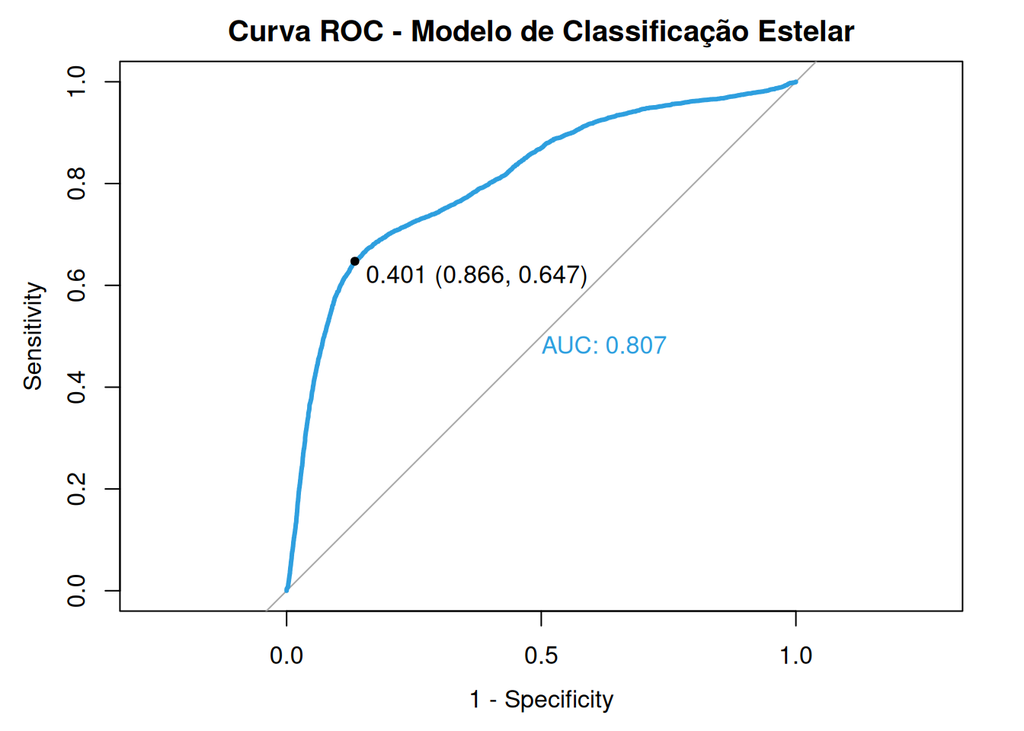

Como se pode observar no gráfico, o modelo apresenta uma boa capacidade discriminatória, registando um AUC (Area Under the Curve) de $0,807$. Adicionalmente, a análise da curva sugere que o fraco desempenho na Sensibilidade verificado na matriz de confusão pode ser mitigado. O gráfico assinala um ponto ótimo de corte a rondar os $0,401$ (em vez do habitual $0,5$), o qual permitiria um compromisso muito mais equilibrado entre a sensibilidade e a especificidade na classificação das estrelas e galáxias.

Isto significa que reduzindo o limiar para 0.401 o modelo ficaria muito mais equilibrado, mitigando o facto de existirem muitas mais galáxias do que estrelas.

## 8. Verificação das Condições de Aplicabilidade

### 8.1 Verificação da linearidade do logit

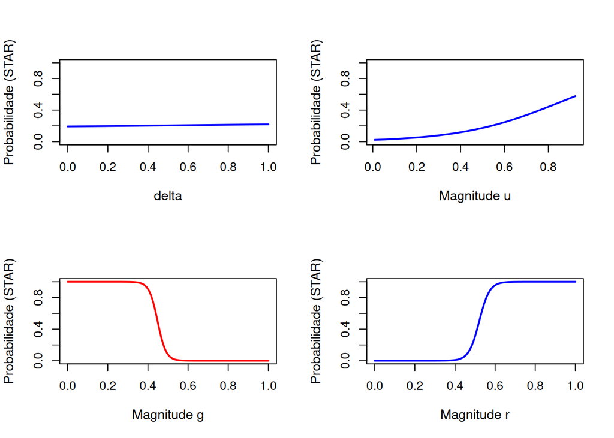

Analisando o gráfico referente a cada variável é observável a probabilidade de um objecto ser classificado com classe *STAR* à medida que o valor da variável varia.

`Delta` tem uma linha quase plana o que mostra que não importa o quanto esta variável mude, a probabilidade do objeto ter esta classificação muda muito pouco. A linha de `u` cresce à medida que este aumenta, ou seja, quanto maior for esta variável maior a chance do objeto ter esta classe.